# Municipal Crime in Residential Subdivisions

## 5.1 Data Aggregation By Residential Subdivision

We describe data correction and data aggregation steps.

```
##
## Call:
## lm(formula = div$shape_starea ~ div$approvedlots)
##
## Residuals:
##      Min       1Q   Median       3Q      Max
## -4433751  -373566  -119874   318529 19801364
##
## Coefficients:
##                  Estimate Std. Error t value Pr(>|t|)
## (Intercept)      218299.4    76811.9   2.842  0.00461 **
## div$approvedlots  12244.8      525.4  23.307  < 2e-16 ***
## ---
## Signif. codes:  0 '***' 0.001 '**' 0.01 '*' 0.05 '.' 0.1 ' ' 1
##
## Residual standard error: 1535000 on 711 degrees of freedom
## Multiple R-squared:  0.4331, Adjusted R-squared:  0.4323
## F-statistic: 543.2 on 1 and 711 DF,  p-value: < 2.2e-16
```

|  | div_id | name | shape_starea | approvedlots | geometry |
| --- | --- | --- | --- | --- | --- |
| 414 | 414 | Arrington Woods | 138663.3 | 0 |  |
| 419 | 419 | Summercrest Two | 627791.4 | 0 |  |
| 706 | 706 | Searstone | 2700843.1 | 0 |  |

Residential Subdivisions with Imputed Approved Lots

| name | category | approvedlots |
| --- | --- | --- |
| Arrington Woods | Condo | 11 |
| Summercrest Two | Single Family Detached | 33 |
| Searstone | Mixed Residential | 573 |

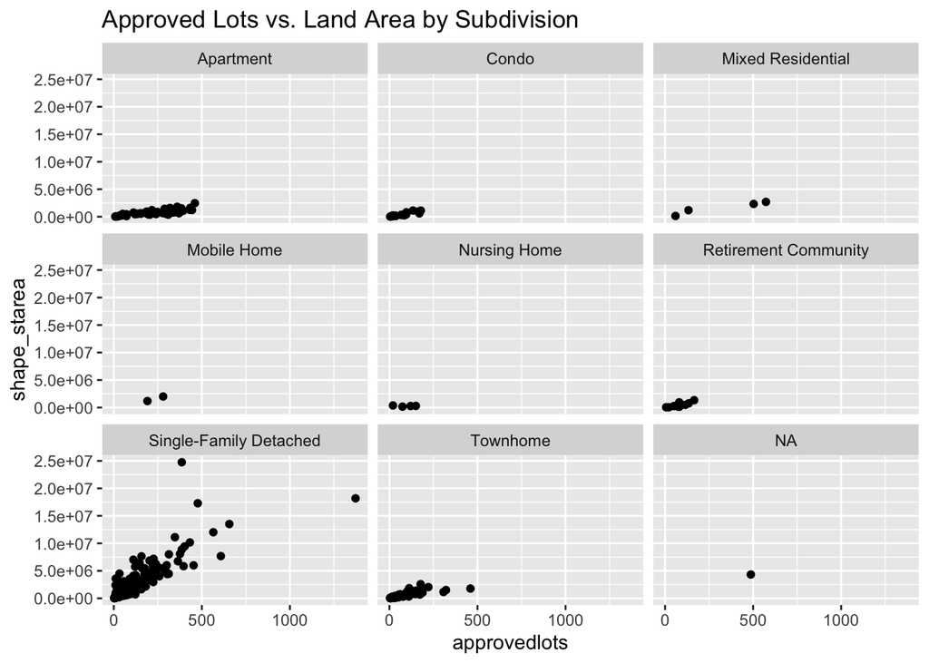

One observation *Brickyard* had a missing category which we manually assigned to *Townhome* by an Internet search. The frequency table of subdivision categories is shown as follows.

| Var1 | Freq |
| --- | --- |
| Apartment | 67 |
| Condo | 19 |
| Mixed Residential | 4 |
| Mobile Home | 2 |
| Nursing Home | 4 |
| Retirement Community | 10 |
| Single-Family Detached | 481 |
| Townhome | 126 |

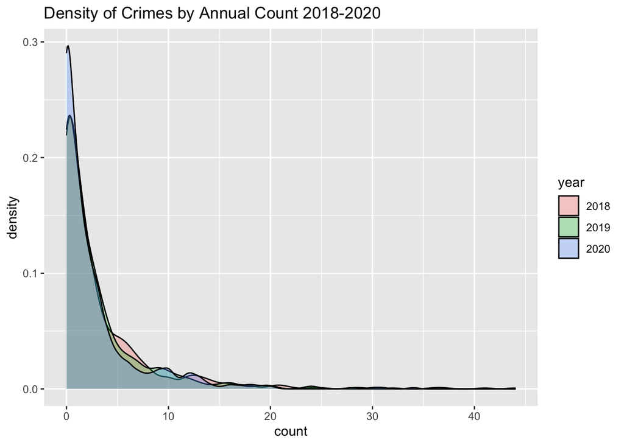

Lastly, we visualize each year’s crime level geographically below. We can see the clear presence of high crime levels in a small number of subdivisions that persist across the 3 years while most subdivisions are low crime. We also see the presence of some clusters that suggest spatial dependencies.

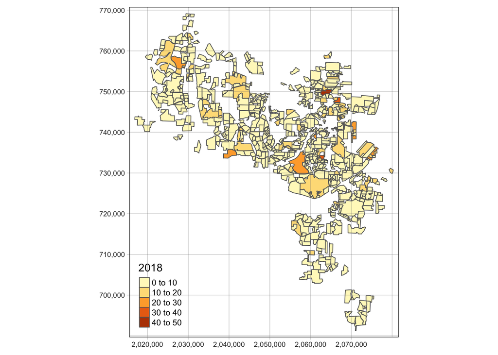

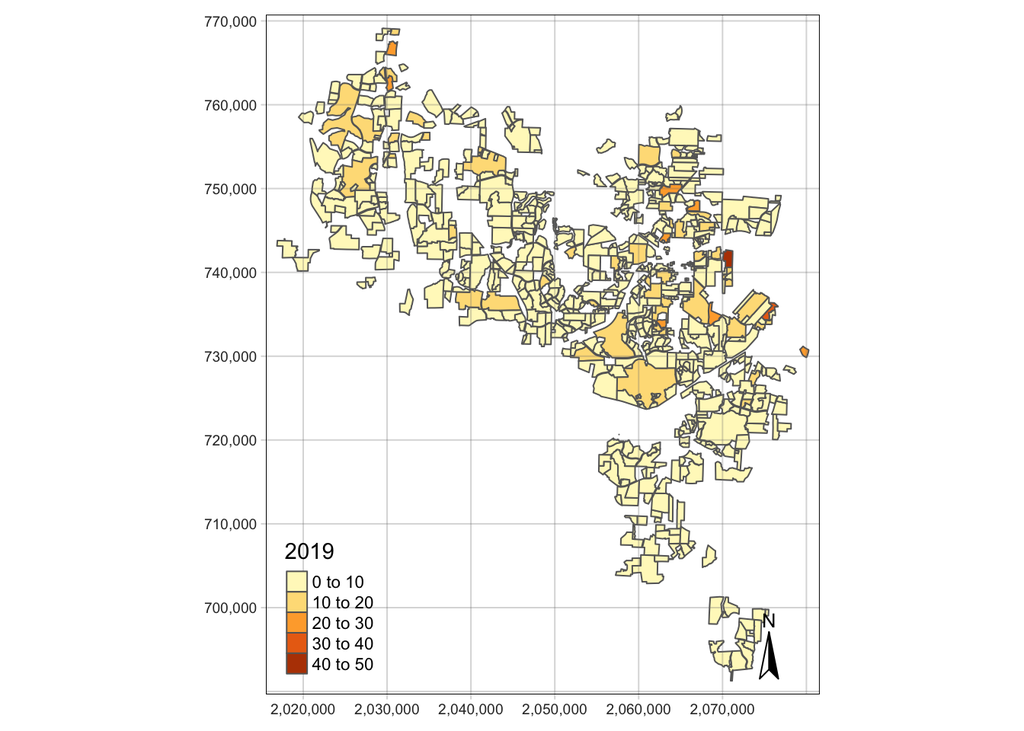

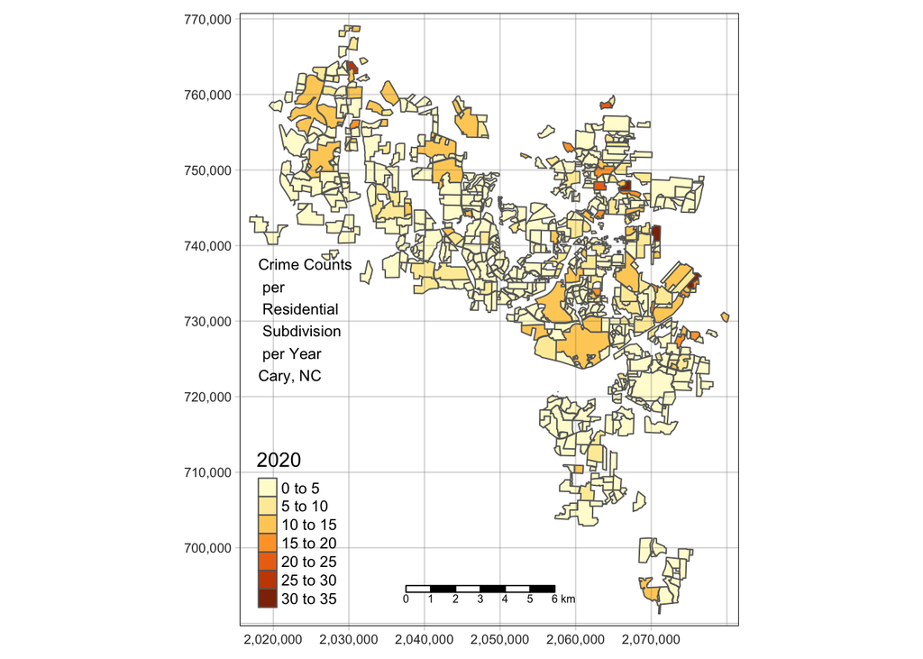

## 5.2 Regressions

We construct regression models to predict crime levels 2019 in terms of static variables and 2018 crime levels. We run both a standard OLS model that ignores spatial dependencies and a spatial lag model includes those dependencies in the analysis. The OLS results are reported below.

```
##
## Call:
## lm(formula = `2019` ~ `2018` + avg_income + approvedlots + shape_starea +
##     factor(category), data = regdivdata)
##
## Residuals:
##      Min       1Q   Median       3Q      Max
## -10.7876  -1.0930  -0.3515   0.6842  18.8328
##
## Coefficients:
##                                          Estimate Std. Error t value Pr(>|t|)
## (Intercept)                             3.448e+00  5.526e-01   6.240 7.56e-10
## `2018`                                  4.646e-01  2.919e-02  15.915  < 2e-16
## avg_income                             -1.036e-05  3.173e-06  -3.265  0.00115
## approvedlots                            1.097e-02  1.658e-03   6.618 7.22e-11
## shape_starea                            1.844e-08  7.955e-08   0.232  0.81674
## factor(category)Condo                  -1.876e+00  7.238e-01  -2.592  0.00974
## factor(category)Mixed Residential      -1.364e+00  1.367e+00  -0.998  0.31858
## factor(category)Mobile Home             1.301e+01  1.872e+00   6.946 8.59e-12
## factor(category)Nursing Home           -3.353e+00  1.354e+00  -2.476  0.01353
## factor(category)Retirement Community   -2.308e+00  9.134e-01  -2.527  0.01172
## factor(category)Single-Family Detached -2.145e+00  4.682e-01  -4.581 5.47e-06
## factor(category)Townhome               -2.409e+00  4.744e-01  -5.078 4.90e-07
##
## (Intercept)                            ***
## `2018`                                 ***
## avg_income                             **
## approvedlots                           ***
## shape_starea
## factor(category)Condo                  **
## factor(category)Mixed Residential
## factor(category)Mobile Home            ***
## factor(category)Nursing Home           *
## factor(category)Retirement Community   *
## factor(category)Single-Family Detached ***
## factor(category)Townhome               ***
## ---
## Signif. codes:  0 '***' 0.001 '**' 0.01 '*' 0.05 '.' 0.1 ' ' 1
##
## Residual standard error: 2.596 on 701 degrees of freedom
## Multiple R-squared:  0.6766, Adjusted R-squared:  0.6715
## F-statistic: 133.3 on 11 and 701 DF,  p-value: < 2.2e-16
```

To run a spatial regression, we first have to build a spatial weight matrix based on the dependencies between subdivisions. We have a choice of contiguity by region or distanced based locations. We ruled out two standard methods after experimentation.

- Regional contiguity left too many isolated subdivisions (over 90) which was unacceptable because these subdivisions would have zero contribution to spatial dependencies.
- Distance banded weight matrix - required a very large distance threshold to ensure no isolated subdivisions.

We settled on a k-nearest neighbor spatial dependency matrix for $k=6$. Among the neighbors, we define an inverse distance weighted measure and then row-standardized the weights for each observation (subdivision). In particular, we define the raw weight $rw[i,j]$ of a subdivision $i$ to its neighbor $j$ as:

$$rw[i,j] = \frac{1}{\lVert c(i)-c(j)\rVert^{\alpha}} \text{ where } \alpha = 0.5$$
Then we define the row standardized weights $w[i,j]$ in a matrix $W$ as:

$$w[i,j] = \frac{rw[i,j]}{\sum_{h=1}^{N} rw[i,h]} \text{ where } N = \text{ number of subdivisions}$$

Surprisingly, $\alpha=2$ causes the Lagrange multipler spatial dependency tests to fail to be statistically sigificant whereas $\alpha=1$ and $\alpha=0.5$ produces strong results. Because the distance-based weights are not scale independent, (we use feet to measure distances), we attribute this statistical significance effect to the fact the decay rate of the weights. A large $\alpha$ makes the weights decay too fast.

[Applications of Spatial Weights: R Notes by Luc Anselin and Grant Morrison] (https://spatialanalysis.github.io/lab_tutorials/Applications_of_Spatial_Weights.html#spatially-lagged-variables)

We plot the spatial weights matrix below with edges in red to show the connection strength and each dot representing the centroid of a subdivision plotted by its geographic coordinates. We see the presence of some connected components but no isolates.

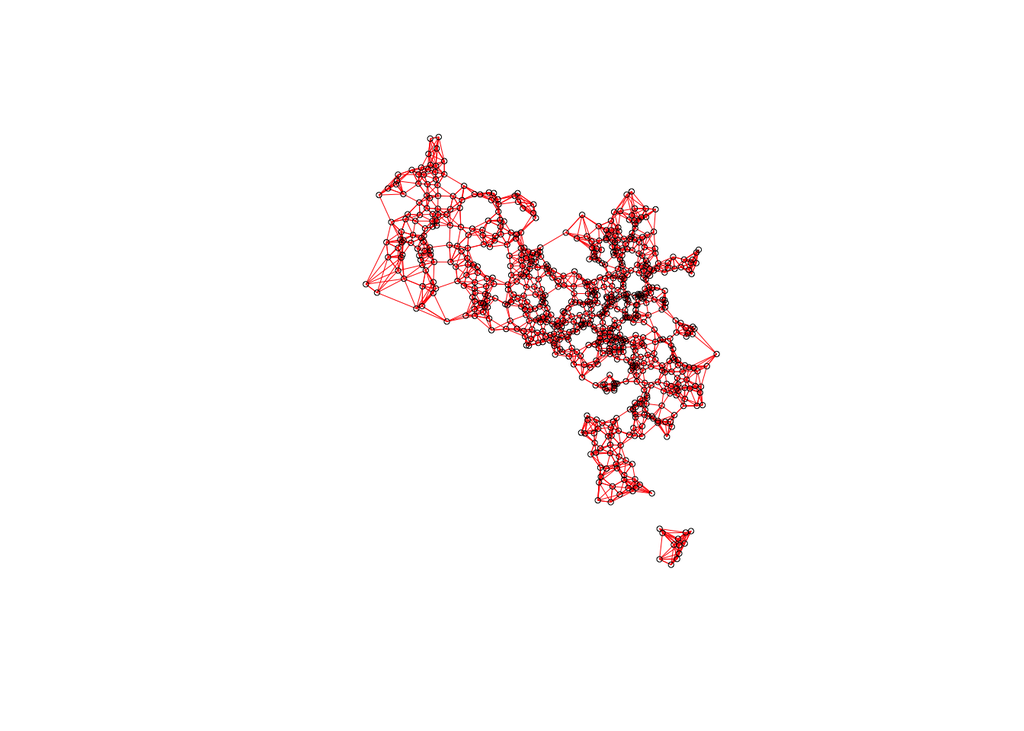

To identify the type of spatial regression model to run, we use the Lagrange multipler tests. To identify the presence of spatial dependencies, we use Moran’s I-statistic. The Lagrange multiplier test for the spatial weights $W$ and above OLS model show that a spatial lag model is appropriate with p-value of 0.88% significance but a spatial errors model is not with a p-value of 86% significance.

```
##
##  Lagrange multiplier diagnostics for spatial dependence
##
## data:
## model: lm(formula = `2019` ~ `2018` + avg_income + approvedlots +
## shape_starea + factor(category), data = regdivdata)
## weights: wts_k6_a2
##
## LMlag = 6.8475, df = 1, p-value = 0.008876
##
##
##  Lagrange multiplier diagnostics for spatial dependence
##
## data:
## model: lm(formula = `2019` ~ `2018` + avg_income + approvedlots +
## shape_starea + factor(category), data = regdivdata)
## weights: wts_k6_a2
##
## LMerr = 0.030031, df = 1, p-value = 0.8624
```

Moran’s I statistic on the response variable `2019` crime levels shows spatial dependencies exist. Clustering exists and is highly statistically significant. Moran’s I statistic shows a value of 0.17 while p-value is nearly 0.

```
##
##  Moran I test under randomisation
##
## data:  regdivdata$`2019`
## weights: wts_k6_a2
##
## Moran I statistic standard deviate = 8.3061, p-value < 2.2e-16
## alternative hypothesis: greater
## sample estimates:
## Moran I statistic       Expectation          Variance
##       0.171497419      -0.001404494       0.000433319
```

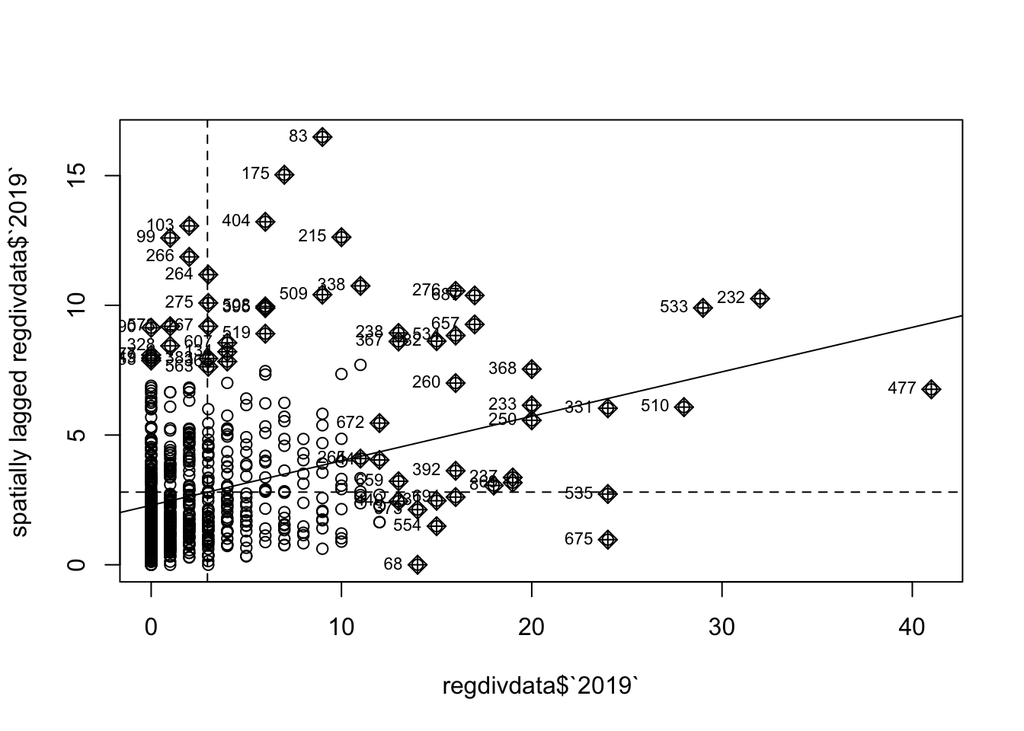

We summarize the spatial lags model below.

```
##
## Call:lagsarlm(formula = `2019` ~ `2018` + avg_income + approvedlots +
##     shape_starea + factor(category), data = regdivdata, listw = wts_k6_a2)
##
## Residuals:
##       Min        1Q    Median        3Q       Max
## -11.06162  -1.10105  -0.31190   0.71921  18.53291
##
## Type: lag
## Coefficients: (numerical Hessian approximate standard errors)
##                                           Estimate  Std. Error z value
## (Intercept)                             2.9254e+00  5.8551e-01  4.9964
## `2018`                                  4.5637e-01  2.8982e-02 15.7468
## avg_income                             -8.6747e-06  3.2055e-06 -2.7062
## approvedlots                            1.0749e-02  1.6173e-03  6.6467
## shape_starea                            3.1606e-08  7.6713e-08  0.4120
## factor(category)Condo                  -1.7017e+00  7.1793e-01 -2.3704
## factor(category)Mixed Residential      -1.4572e+00  1.3508e+00 -1.0788
## factor(category)Mobile Home             1.2714e+01  1.8509e+00  6.8689
## factor(category)Nursing Home           -3.1718e+00  1.3387e+00 -2.3693
## factor(category)Retirement Community   -2.1735e+00  9.0251e-01 -2.4083
## factor(category)Single-Family Detached -2.0375e+00  4.6317e-01 -4.3990
## factor(category)Townhome               -2.3418e+00  4.6861e-01 -4.9975
##                                         Pr(>|z|)
## (Intercept)                            5.841e-07
## `2018`                                 < 2.2e-16
## avg_income                              0.006806
## approvedlots                           2.998e-11
## shape_starea                            0.680339
## factor(category)Condo                   0.017771
## factor(category)Mixed Residential       0.280661
## factor(category)Mobile Home            6.472e-12
## factor(category)Nursing Home            0.017820
## factor(category)Retirement Community    0.016025
## factor(category)Single-Family Detached 1.088e-05
## factor(category)Townhome               5.808e-07
##
## Rho: 0.10234, LR test value: 6.1576, p-value: 0.013085
## Approximate (numerical Hessian) standard error: 0.04097
##     z-value: 2.4979, p-value: 0.012492
## Wald statistic: 6.2397, p-value: 0.012492
##
## Log likelihood: -1682.663 for lag model
## ML residual variance (sigma squared): 6.5567, (sigma: 2.5606)
## Number of observations: 713
## Number of parameters estimated: 14
## AIC: 3393.3, (AIC for lm: 3397.5)
```

## 5.3 Discussion

The equation defining the model can be written as:

$$y=\rho W y + \mathbf{X}b + u$$

where the response variable $y$ is a $N \times 1$ vector. $\rho$ is the spatial autoregressive coefficient and $W$ is the $N \times N$ spatial weights matrix described earlier. $\mathbf{X}$ is the matrix of subdivision level data either crime in 2018 and static characteristic data. $u$ is the vector of random error terms.

We observe a low but significant spatial dependency between crime levels in adjoining residential subdivisions. The spatial lag regression is statistically significant as $\rho = 0.10$ and its p-value $p=1.31\%$ is significant at the 5% level.

Examining the coefficients, we see the past crime level `2018` is very statistically significant $p < 2.2 \times 10^{-16}$ at expected sign and magnitude. Likewise, the number of approved lots is also very significant $p=3.0 \times 10^{-11}$ while the coefficient is positive and small. Average income is highly significant and negatively related to crime levels as expected with $p=0.68%$. The area in the subdivision is not statistically significant and the coefficient is nearly zero. Lastly, we consider the category of subdivision. `category`=`Mobile Home` has a very strong positive association with higher crime levels while all other types of subdivisions are negatively related.

We conclude that a $100,000 increase in median household income (`avg_income`) would be associated with 0.86 fewer incidents per year after incorporating the past year’s crime level. By comparison with the OLS model, the coefficients are larger. A $100,000 increase in `avg_income` reduces crime by 1.03 incident per year. This difference is because the OLS model does not control for spatial clustering.

As a sensitivity check, if we exclude past crime levels as a predictor in the spatial lag model, the coefficient for `avg_income` grows larger. In that case, a $100,000 increase in `avg_income` reduces crime by 1.7 instead of .86 incidents per year per subdivision.

Interestingly, crime levels appear unrelated to the square footage of the subdivision `shape_starea`. Perhaps, crime rarely occurs on empty land but requires the inhabitants as perpetrators and victims.

However, crime level in the Town of Cary appear relatively low. The median number of crimes is 1 incident per year per subdivision while the mean is around 3. The relatively modest spatial autoregressive coefficient may be explained by two effects: the low overall level of crime - in some cases - 1 incident per year and the geographic dispersion of the subdivisions. Some subdivisions are geographically isolated from others. Adjacent subdivisions are often separated by landscaping and trees with no connecting paths or roads. Sometimes you cannot walk between subdivisions except along arterial public highways.

# 6 Conclusion

Spatial regression is a fruitful method to investigate crime incidents in residential subdivisions. A recent literature survey [Kounadi, Ristea, et. al, 2020](https://doi.org/10.1186/s40163-020-00116-7) found 193 papers in spatial crime forecasting. None of the top 32 papers used residential subdivisions as spatial unit of measure. Most papers used geographic grids or broader regions like districts, cities or counties. One challenge of using residential subdivisions is their heterogeneity of purposes and population and geographic dispersion. A benefit of using residential subdivisions is that they are actual communities - often defined by a homeowner association with like-minded residents.

We experimented with non-traditional spatial weight measures to overcome technical challenges to conducting spatial regressions and produce intuitively sensible model coefficients. We conjecture that spatial dependency in the Town is local rather than global.  
A future direction of study is to use localized spatial regression analysis to analyze crime in such a sprawling town.

# 7 Appendices

## 7.1 References

National Incident-Based Reporting System (NIBRS) codes are described in the 2019 update: (https://www.fbi.gov/file-repository/ucr/ucr-2019-1-nibrs-technical-specification.pdf/view)

Vignettes for the use of `sf` package in R by Edzer Pebesma: (https://r-spatial.github.io/sf/articles/)

[Crime Prediction & Monitoring Framework Based on Spatial Analysis] (https://www.sciencedirect.com/science/article/pii/S187705091830807X)

[Dash, Safro, Srinivasamurthy 2018] Spatio-temporal prediction of crimes using network analytic approach (https://arxiv.org/abs/1808.06241)

[Kounadi, Ristea, et al.(2020). A systematic review on spatial crime forecasting. Crime Science 9:7](https://doi.org/10.1186/s40163-020-00116-7)

Bivand, Pebesma, Gomez-Rubio **Applied Spatial Data Analysis with R** (http://gis.humboldt.edu/OLM/r/Spatial%20Analysis%20With%20R.pdf)

Lansley, Cheshire **An Introduction to Spatial Data Analysis and Visualisation in R** (https://spatialanalysisonline.com/An%20Introduction%20to%20Spatial%20Data%20Analysis%20in%20R.pdf)

## 7.2 Disclaimer

## 7.3 Code

We summarize all the R code used in this project in this appendix for ease of reading.

```r
library(knitr)
# ---------------------------------
knitr::opts_chunk$set(echo = FALSE, message=FALSE, warning=FALSE)


# Your libraries go here

library(tidyverse)
library(ggplot2)
library(ggrepel)
library(kableExtra)
library(dplyr)

library(caret)   # Model Framework
library(skimr)    # Used for EDA
library(klaR)     # Implemented KNN and Naive Bayes models, etc

# PLEASE ADD YOUR R LIBRARIES BELOW
# ------------------------------
library(janitor)  # used for tabyl function
library(sf)     # used for spatial data load and calculations
library(tmap)   # used for plotting maps
library(spdep)


# Alex:
# This code chunk is only to be used for conditionally disabling certain
# very slow model code as I merge different sections and need to frequent recompile
runSlowChunks = F


# Load the raw data for the town boundary
town_raw = sf::st_read("cary_boundary.geojson", quiet = TRUE)

# Load the raw data for the census
acs_raw = sf::st_read("acs2018_5yr_B19013_14000US37183053513.geojson", quiet = TRUE)

# Load the subdivisions
div_raw = sf::st_read("httpmapstownofcary0.geojson", quiet = TRUE)



cpd_raw = sf::st_read("cpd-incidents.geojson", quiet = TRUE)
dataset_sizes = data.frame( town_limits = as.character( dim(town_raw) ) ,
                            acs_income  = as.character( dim(acs_raw) ) ,
                            subdivisions = as.character( dim(div_raw) ),
                            crimes       = as.character( dim(cpd_raw) ) )

dataset_sizes = rbind( dataset_sizes, c("Town of Cary", "Censusreporter.org", "Town of Cary", "Town of Cary Police Department"))
row.names(dataset_sizes) = c("number rows", "number columns", "source")


dataset_sizes %>% kable( caption = "Raw data file dimensions" ) %>% kable_styling(bootstrap_options = c("striped", "hover"))
#
# Use the North Carolina NAD83 Projected CRS
# --------------------------------------------------
town = st_transform(town_raw, 2264)

# Remove any observations (subdivisions) where geometry data is missing.
#
div = div_raw %>% filter(  !is.na(st_dimension(div_raw) ) )

print(paste0("raw subdivisions data: ",  nrow(div_raw), " vs. ", "tidied subdivisions data: ", nrow(div)))

# Add an integer identifier to the subdivisions dataframe as there is no unique key (except geometry)
div = tibble::rowid_to_column(div, "div_id")

# Change the CRS coordinate system from WGS84 to NAD83/North Carolina
# in order to allow distance measurement, etc.
div = st_transform(div, 2264)


# Change the coordinate system for the ACS survey data to EPSG 2264 North Carolina ft-US
acs = st_transform(acs_raw, 2264)

acs = acs %>% rename(tract_name = name ) %>%
  rename( income = B19013001 ) %>%  dplyr::select( -one_of(c("B19013001..Error") ) )

head(acs, 5) %>% kable() %>% kable_styling(bootstrap_options = c("striped", "hover"))
summary(acs$income)
#  Calculation all the intersections between census tracts and
#  residential subdivisions
#
div_acs_partition = st_intersection( div, acs)

dim(div_acs_partition)
df_div_acs_areas = data.frame( area = as.numeric( st_area(div_acs_partition) ),
                               tract_name = div_acs_partition$tract_name ,
                               name = div_acs_partition$name,
                               div_id = div_acs_partition$div_id,
                               income = div_acs_partition$income )
df_div_acs_areas %>% group_by(div_id) %>%
                   summarize(avg_income = weighted.mean(income, area) ,
                             count = n(),
                             max_id = max(div_id)
                             ) -> div_avg_income

div %>% dplyr::left_join( div_avg_income, by = 'div_id') %>%
  dplyr::select( div_id, category, name,
                  shape_stlength, shape_starea, approvedlots, description, geo_point_2d,
                 avg_income, geo_point_2d) -> div

head(div, n = 3 ) %>% kable() %>% kable_styling(bootstrap_options = c("striped", "hover") )


# Only use the years 2018-2020 and drop those with missing or invalid geometry information.
#
cpd2018_2020 = cpd_raw %>% filter( !is.na(st_geometry(cpd_raw)))  %>%
                    filter(!is.na(st_dimension(cpd_raw))) %>%
                     filter(  year == "2018" | year == "2019" | year == "2020" ) # %>%  slice(1:10)

crimes = cpd2018_2020 %>% dplyr::select(incident_number, newdate, year,
                                        ucr , crime_type, crime_category, offensecategory,
                                        lon, lat, geocode, district)

# Change the coordinate system to NAD83/North Carolina ft US
crimes = st_transform(crimes, 2264)

dim(crimes)

head(crimes[c(1,3000,4000,6000), c("incident_number", "newdate", "ucr", "crime_type", "crime_category",
                                   "geocode", "district")], n=4) %>% kable() %>% kable_styling(bootstrap_options = c("striped", "hover"))
crimesdiv = st_join(crimes, div, join = st_within , left = FALSE)

dim(crimesdiv)

crimesdiv %>% group_by(year) %>% summarize(count=n())

sf::st_write(crimesdiv, "crimesdiv.geojson", append = FALSE, delete_dsn = TRUE, quiet = TRUE)
sf::st_write(div, "div.geojson", append = FALSE, delete_dsn = TRUE, quiet = TRUE)

crimesdiv = st_read("crimesdiv.geojson")

div = st_read("div.geojson")


g = lm(div$shape_starea ~ div$approvedlots )

summary(g)

div[which(div$approvedlots == 0), ] %>% dplyr::select(div_id, name, shape_starea, approvedlots)

div$approvedlots[414] = 11   # Arrington Woods  Condo
div$approvedlots[419] = 33   # Summercrest Two Single Family Detached
div$approvedlots[706] = 573  # Searstone Mixed residential

impute_approvedlots = data.frame(name = c("Arrington Woods", "Summercrest Two", "Searstone" ),
                                 category = c("Condo", "Single Family Detached", "Mixed Residential") ,
                                 approvedlots = c( 11, 33, 573 ) )

impute_approvedlots %>% kable(caption="Residential Subdivisions with Imputed Approved Lots") %>% kable_styling( bootstrap_options = c("striped", "hover"))


ggplot(data=div) + geom_point(aes(x=approvedlots, y=shape_starea)) + facet_wrap(~category) + ggtitle("Approved Lots vs. Land Area by Subdivision")


div[which(div$name == "Brickyard"),]$category = "Townhome"  # Manually checked that Brickyard is a townhome subdivision and category is NA

table(div$category, useNA='ifany') %>% kable() %>% kable_styling(bootstrap_options = c("striped", "hover"))


# Save the crime counts by year and residential subdivision
# Fill the NA values (i.e. no crimes in year X in subdivision R with 0)
# -------------------------------------------
divfreq = crimesdiv %>% group_by(div_id, year) %>% summarize( count = n()) %>%
  st_drop_geometry() %>%
  pivot_wider(names_from = year, values_from = count, values_fill = 0  )


regdivdata = div %>% left_join(divfreq, by="div_id") %>% mutate( `2018` = coalesce(`2018`, 0), `2019` = coalesce(`2019`, 0 ), `2020` = coalesce(`2020`, 0 ) )

regdivdata = regdivdata %>% mutate( cr2018 = `2018`/approvedlots, cr2019 = `2019`/approvedlots, cr2020 = `2020`/approvedlots)

#head(regdivdata) %>% kable() %>% kable_styling(bootstrap_options = c("striped", "hover,"))

regdivdata %>% dplyr::select(div_id, `2018`, `2019` , `2020`) %>% st_drop_geometry() %>% pivot_longer(!div_id, names_to="year", values_to="count" ) %>% ggplot() + geom_density(aes(x=count, fill=year), alpha = 0.3) +
  ggtitle("Density of Crimes by Annual Count 2018-2020")


qtm2018 = qtm(regdivdata, "2018") + tm_grid(alpha=0.3)

qtm2019 = qtm(regdivdata, "2019") + tm_grid(alpha=0.3) + tm_compass()

qtm2020 = qtm(regdivdata, "2020") + tm_scale_bar(position=c("center", "bottom" ) ) + tm_grid(alpha=0.3) +
    tm_credits("Crime Counts \n per \n Residential\n Subdivision\n per Year\nCary, NC" , position=c("left", "center"), width=0.25, align="left" )

qtm2018

qtm2019

qtm2020

#tmap_arrange(qtm2018, qtm2019, qtm2020, asp = 1.5, ncol = 1)


#gm1 = lm( cr2019 ~ cr2018 + avg_income + approvedlots + shape_starea + factor(category), data = regdivdata)

OLS2 = lm( `2019` ~ `2018` + avg_income + approvedlots + shape_starea + factor(category), data = regdivdata)
summary(OLS2)

c_div = st_centroid( st_geometry(div))

k6 = knn2nb( knearneigh(st_centroid( st_geometry(div)), k = 6), row.names = div$div_id)

k6.weights = nb2listw(k6)

wts_k6_a2 = nb2listwdist(k6, c_div, type = "idw", style="W", alpha=0.5)

#summary(wts_k6_a2)


#k4 = knn2nb( knearneigh(st_centroid( st_geometry(div)), k = 4), row.names = div$div_id)

#k4.weights = nb2listw(k4)

#wts_k4_a2 = nb2listwdist(k4, c_div, type = "idw", style="W", alpha=0.5)


#k3 = knn2nb( knearneigh(st_centroid( st_geometry(div)), k = 3), row.names = div$div_id)

#k2.weights = nb2listw(k3)

#wts_k3_a2 = nb2listwdist(k6, c_div, type = "idw", style="W", alpha=0.5)



# diagram of the spatial weights linkages.
#
plot(wts_k6_a2, c_div, lwd = .5, col = "red", cex = 0.5)

lm.LMtests(OLS2, wts_k6_a2, test = c("LMlag", "LMerr"))
moran.test( regdivdata$`2019`, wts_k6_a2)
moran.plot( regdivdata$`2019`, wts_k6_a2)

spatial.lag.k6a2 = lagsarlm( `2019` ~ `2018` + avg_income + approvedlots + shape_starea + factor(category),
                           data = regdivdata , wts_k6_a2 )

summary(spatial.lag.k6a2)
```